# Sprint 1 model

2026-10-22

```r
library(dplyr)
library(ggplot2)
```

## Idea

The aim of this model is to predict the Premier League ranking of teams at the end of the season. To do this I will predict the goals scored in each match of the given fixture, convert this into predicted points, add these points up, to then get a final ranking that orders the team with respect to:

1. Total number of points at the end of the season
2. Goal difference at the end of the season.

## Model building

Firstly, I want to visualize the possible variables that might be used to model our prediction.

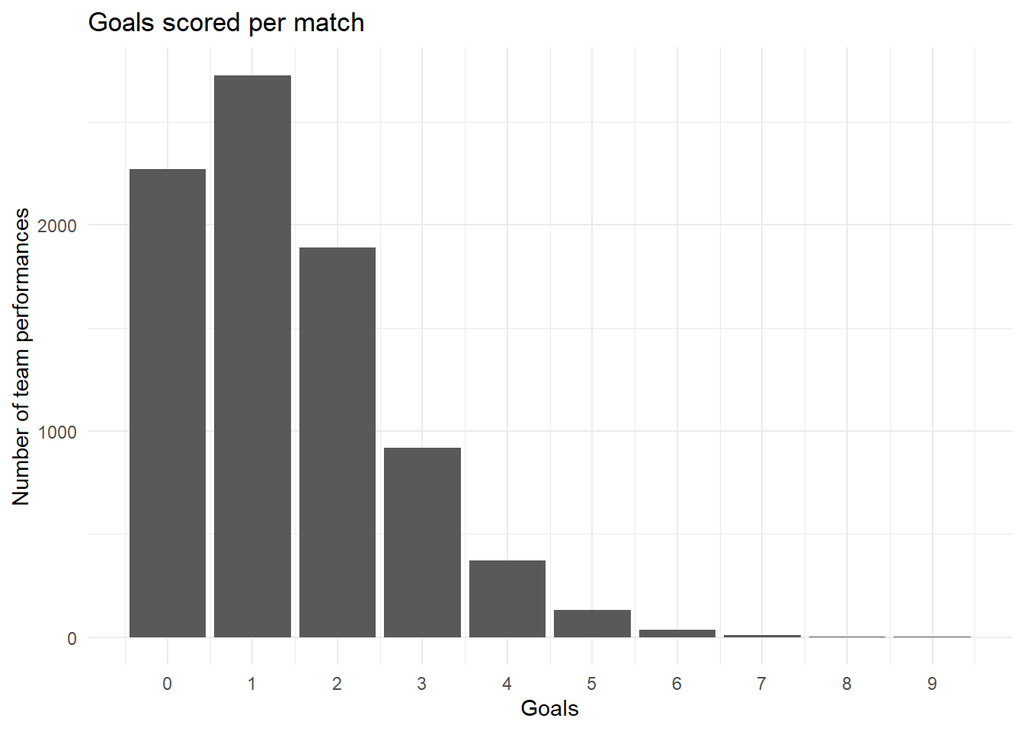

```r
goal_data <- data.frame(Goals = c(train_data$FTHG, train_data$FTAG))

ggplot(goal_data, aes(x = Goals)) + geom_bar() + scale_x_continuous(breaks = 0:max(goal_data$Goals, na.rm = TRUE)) +labs(title = "Goals scored per match",x = "Goals",y = "Number of team performances") + theme_minimal()
```

## Model selection using stepwise method selection and AIC

The model predicts the number of goals scored by the home team and the number scored by the away team. It uses statistics from previous matches as inputs. The current match’s final result and statistics are not used as inputs, because that information would not be available before the match.

Now we look at a stepwise method selection to choose the model with lowest AIC.

```r
set.seed(1)
predictor_columns <- c("HomeFTGoalsBefore", "AwayFTGoalsBefore", "HTPB", "ATPB", "HomeShotsBefore", "AwayShotsBefore", "HomeShotsOnTargetBefore", "AwayShotsOnTargetBefore", "HomeCornersBefore", "AwayCornersBefore", "HomeFoulsBefore", "AwayFoulsBefore", "HomeYellowCardsBefore", "AwayYellowCardsBefore", "HomeRedCardsBefore", "AwayRedCardsBefore")

#variables we want to apply to our model
home_train <- train_data[, c("FTHG", predictor_columns)]
away_train <- train_data[, c("FTAG", predictor_columns)]

#full model formulas
home_full_formula <- reformulate(predictor_columns, response = "FTHG")
away_full_formula <- reformulate(predictor_columns, response = "FTAG")

#null models
home_null <- glm(FTHG ~ 1, data = home_train, family = poisson)
away_null <- glm(FTAG ~ 1, data = away_train, family = poisson)

#forward backward selection using AIC
home_step <- step(home_null, scope = list(lower = ~1, upper = home_full_formula), direction = "both")
```

```
## Start:  AIC=13318.02
## FTHG ~ 1
##
##                           Df Deviance   AIC
## + HTPB                     1   5187.2 13208
## + HomeShotsOnTargetBefore  1   5229.6 13251
## + HomeShotsBefore          1   5251.8 13273
## + HomeCornersBefore        1   5257.7 13279
## + ATPB                     1   5261.5 13282
## + AwayShotsOnTargetBefore  1   5283.7 13305
## + HomeFTGoalsBefore        1   5287.7 13309
## + AwayCornersBefore        1   5289.4 13310
## + AwayYellowCardsBefore    1   5290.1 13311
## + AwayShotsBefore          1   5291.2 13312
## + AwayRedCardsBefore       1   5292.2 13313
## + HomeRedCardsBefore       1   5295.2 13316
## <none>                         5299.0 13318
## + AwayFoulsBefore          1   5297.5 13318
## + HomeYellowCardsBefore    1   5298.1 13319
## + AwayFTGoalsBefore        1   5298.6 13320
## + HomeFoulsBefore          1   5298.7 13320
##
## Step:  AIC=13208.19
## FTHG ~ HTPB
##
##                           Df Deviance   AIC
## + ATPB                     1   4886.4 12909
## + AwayShotsOnTargetBefore  1   4899.8 12923
## + AwayCornersBefore        1   4900.0 12923
## + AwayShotsBefore          1   4912.8 12936
## + HomeFoulsBefore          1   4996.8 13020
## + AwayFTGoalsBefore        1   5023.0 13046
## + AwayFoulsBefore          1   5038.1 13061
## + HomeYellowCardsBefore    1   5057.7 13081
## + HomeFTGoalsBefore        1   5101.0 13124
## + AwayYellowCardsBefore    1   5132.1 13155
## + HomeShotsBefore          1   5132.4 13155
## + HomeCornersBefore        1   5135.6 13158
## + HomeRedCardsBefore       1   5151.4 13174
## + HomeShotsOnTargetBefore  1   5163.6 13187
```

[output cut: 192 more lines]

```
## - HomeCornersBefore        1   4811.5 12844
## + AwayRedCardsBefore       1   4807.7 12845
## + HomeShotsOnTargetBefore  1   4807.9 12845
## - AwayFoulsBefore          1   4812.1 12845
## + AwayShotsBefore          1   4808.4 12845
## + AwayFTGoalsBefore        1   4808.4 12845
## + AwayShotsOnTargetBefore  1   4808.6 12846
## + HomeYellowCardsBefore    1   4808.6 12846
## + HomeRedCardsBefore       1   4808.7 12846
## - AwayYellowCardsBefore    1   4816.1 12849
## - HomeShotsBefore          1   4816.7 12850
## - AwayCornersBefore        1   4820.3 12853
## - HomeFoulsBefore          1   4820.7 12854
## - HTPB                     1   4840.8 12874
## - ATPB                     1   4847.6 12881
```

```r
away_step <- step(away_null, scope = list(lower = ~1, upper = away_full_formula), direction = "both")
```

```
## Start:  AIC=12362.34
## FTAG ~ 1
##
##                           Df Deviance   AIC
## + ATPB                     1   5321.1 12308
## + HTPB                     1   5321.2 12308
## + AwayShotsOnTargetBefore  1   5335.5 12322
## + AwayShotsBefore          1   5350.9 12338
## + HomeShotsOnTargetBefore  1   5352.5 12339
## + AwayCornersBefore        1   5354.8 12342
## + HomeShotsBefore          1   5359.5 12346
## + HomeCornersBefore        1   5364.2 12351
## + AwayFTGoalsBefore        1   5372.6 12360
## + HomeYellowCardsBefore    1   5374.0 12361
## + AwayYellowCardsBefore    1   5374.8 12362
## + AwayFoulsBefore          1   5375.1 12362
## <none>                         5377.5 12362
## + HomeRedCardsBefore       1   5375.9 12363
## + HomeFTGoalsBefore        1   5376.8 12364
## + AwayRedCardsBefore       1   5376.9 12364
## + HomeFoulsBefore          1   5377.5 12364
##
## Step:  AIC=12307.98
## FTAG ~ ATPB
##
##                           Df Deviance   AIC
## + HTPB                     1   5046.1 12035
## + HomeShotsOnTargetBefore  1   5080.4 12069
## + HomeShotsBefore          1   5080.9 12070
## + HomeCornersBefore        1   5112.7 12102
## + AwayFoulsBefore          1   5187.5 12176
## + HomeFTGoalsBefore        1   5213.9 12203
## + HomeFoulsBefore          1   5225.1 12214
## + AwayYellowCardsBefore    1   5232.8 12222
## + AwayFTGoalsBefore        1   5269.2 12258
## + HomeYellowCardsBefore    1   5290.2 12279
## + AwayCornersBefore        1   5299.8 12289
## + AwayShotsBefore          1   5300.6 12290
## + AwayRedCardsBefore       1   5308.4 12297
## + HomeRedCardsBefore       1   5316.9 12306
```

[output cut: 170 more lines]

```
## + HomeFoulsBefore          1   4965.7 11966
## + HomeFTGoalsBefore        1   4965.7 11967
## + ATPB                     1   4965.8 11967
## - AwayRedCardsBefore       1   4970.0 11967
## + AwayCornersBefore        1   4966.0 11967
## + HomeCornersBefore        1   4966.1 11967
## + AwayFTGoalsBefore        1   4966.3 11967
## + AwayYellowCardsBefore    1   4966.9 11968
## + HomeRedCardsBefore       1   4967.0 11968
## - AwayShotsBefore          1   4971.7 11969
## - HomeYellowCardsBefore    1   4971.8 11969
## - AwayShotsOnTargetBefore  1   4978.5 11975
## - HomeShotsBefore          1   4982.0 11979
## - AwayFoulsBefore          1   4984.8 11982
## - HTPB                     1   4990.5 11987
```

```r
#full models
home_full <- glm(home_full_formula, data = home_train, family = poisson)
away_full <- glm(away_full_formula, data = away_train, family = poisson)

# comparison
AIC(home_null, home_step, home_full)
```

```
##           df      AIC
## home_null  1 13318.02
## home_step  9 12843.80
## home_full 17 12853.07
```

```r
AIC(away_null, away_step, away_full)
```

```
##           df      AIC
## away_null  1 12362.34
## away_step  8 11965.95
## away_full 17 11975.45
```

For each response, the lowest AIC is the best of the models compared by that criterion. The forward-backward models selected by AIC are:

```r
formula(home_step)
```

```
## FTHG ~ HTPB + ATPB + AwayCornersBefore + HomeFoulsBefore + HomeShotsBefore +
##     AwayYellowCardsBefore + AwayFoulsBefore + HomeCornersBefore
```

```r
formula(away_step)
```

```
## FTAG ~ HTPB + AwayShotsOnTargetBefore + HomeShotsBefore + AwayFoulsBefore +
##     HomeYellowCardsBefore + AwayShotsBefore + AwayRedCardsBefore
```

## Checking the selected models

```r
home_selected_model <- home_step
away_selected_model <- away_step
```

Now, since we’re applying a glm, we want to look at the residual plots for glms.

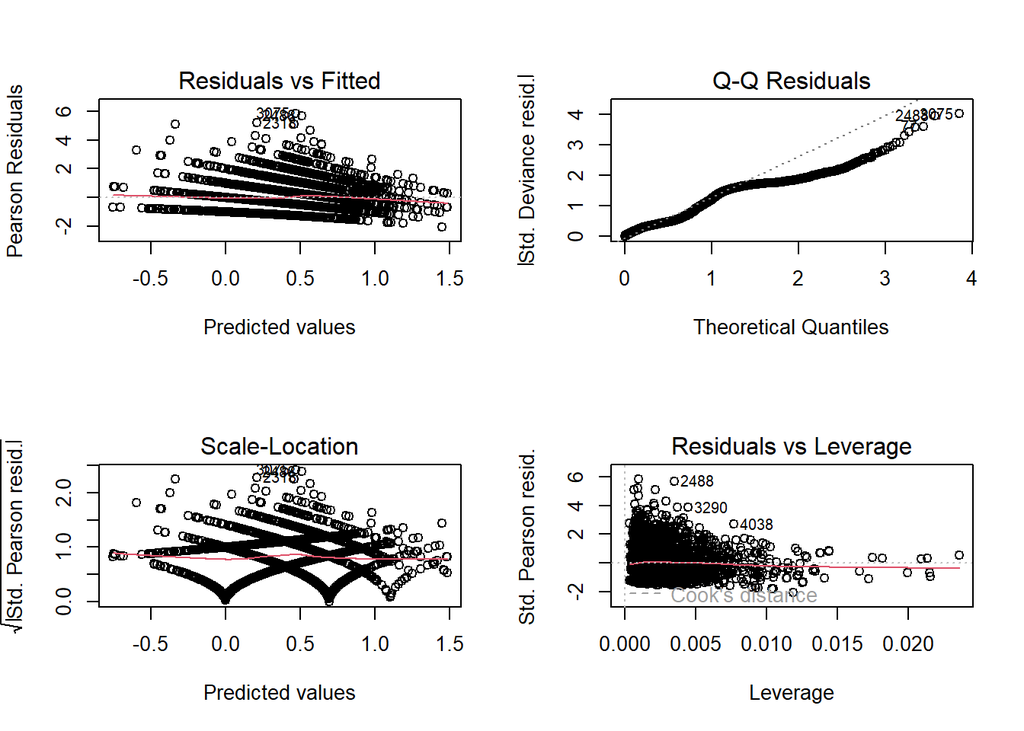

```r
par(mfrow = c(2, 2))
plot(home_selected_model)
```

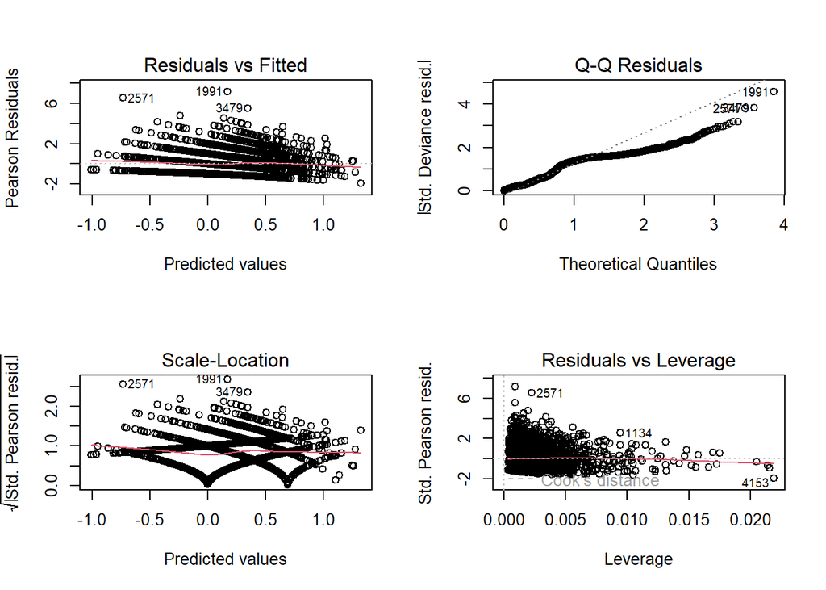

```r
par(mfrow = c(2, 2))
plot(away_selected_model)
```

```r
par(mfrow = c(1, 1))
```

Poisson goals are discrete counts, so their residuals aren’t expected to look like normally distributed residuals. To check whether using this model makes sense we can check the Pearson residuals, which help us check for overdispersion:

```r
c(Home = sum(residuals(home_selected_model, type = "pearson")^2) /df.residual(home_selected_model),
  Away = sum(residuals(away_selected_model, type = "pearson")^2) /df.residual(away_selected_model))
```

```
##     Home     Away
## 1.013235 1.045990
```

Since the Pearson dispersion ratios are close to 1, there is no strong sign of overdispersion as a ratio near 1 is expected for a well-fitting Poisson model.

## Predicting c(Goals scored, goals conceded, points) for each team

### Checking teams

```r
train_teams<-unique(c(train_data$HomeTeam, train_data$AwayTeam))
length(train_teams)
```

```
## [1] 35
```

```r
length(intersect(train_teams, unique(c(test_data$HomeTeam, test_data$AwayTeam))))
```

```
## [1] 20
```

This tells us that from the train data set we have all the teams data from our test set which is great as this gives us more information for all of our observations.

```r
length(intersect(train_teams, unique(c(prediction_data$HomeTeam, prediction_data$AwayTeam))))
```

```
## [1] 19
```

```r
setdiff(unique(c(prediction_data$HomeTeam, prediction_data$AwayTeam)),train_teams)
```

```
## [1] "Coventry"
```

### Model Fitting

Now we fit our selected models.

```r
text_columns <- names(train_data)[sapply(train_data, is.character)] #names the text columns in the dataset
train_data[text_columns] <- lapply(train_data[text_columns], factor) #applies factor() to the text columns
test_data[text_columns] <- lapply(test_data[text_columns], factor) #applies factor() to the text columns

#predict goals for each match in the test season
test_data$PredHomeGoals <- round(predict(home_selected_model, newdata = test_data, type = "response")) #using home model
test_data$PredAwayGoals <- round(predict(away_selected_model, newdata = test_data, type = "response")) #using away model
```

This function turns a set of match scores into a league table:

```r
make_table <- function(matches, home_goals, away_goals) {
  home_table <- data.frame(Team = matches$HomeTeam,
    Points = ifelse(home_goals > away_goals,
                    3,
                    ifelse(home_goals == away_goals,
                           1,
                           0)),GF = home_goals,GA = away_goals)

  away_table <- data.frame(Team = matches$AwayTeam,
    Points = ifelse(away_goals > home_goals,
                    3,
                    ifelse(away_goals == home_goals,
                           1,
                           0)), GF = away_goals,GA = home_goals)

  all_team_matches <- rbind(home_table, away_table)

  table <- aggregate(cbind(Points, GF, GA) ~ Team, data = all_team_matches, sum) #creates the table with all summed up values

  table$GD <- table$GF - table$GA #create new column with each elements following this formula
  table <- table[order(-table$Points, -table$GD), ] #ordering the teams wrt conditions given (i.e. points and gd)
  table$Position <- seq_len(nrow(table)) #adding a column that tells us the index

  table <- table[c("Position", "Team", "Points", "GF", "GA", "GD")]
  rownames(table) <- NULL

  table
}
```

Use it to make both the predicted and actual tables for the test season, then compare positions:

```r
set.seed(1)
predicted_table <- make_table(test_data, test_data$PredHomeGoals, test_data$PredAwayGoals)

actual_table <- make_table(test_data, test_data$FTHG, test_data$FTAG)

table_comparison <- merge(predicted_table, actual_table, by = "Team", suffixes = c("_Predicted", "_Actual"))

table_comparison$PositionDifference <- table_comparison$Position_Predicted - table_comparison$Position_Actual

table_comparison <- table_comparison[order(table_comparison$Position_Actual),]

table_comparison
```

```
##              Team Position_Predicted Points_Predicted GF_Predicted GA_Predicted
## 1         Arsenal                  2               84           63           40
## 13       Man City                  3               83           64           41
## 14     Man United                  1               86           66           45
## 2     Aston Villa                  6               62           54           46
## 12      Liverpool                  4               78           60           42
## 3     Bournemouth                  7               59           53           47
## 17     Sunderland                 16               36           45           54
## 5        Brighton                 11               41           47           53
## 4       Brentford                  9               47           47           47
## 7         Chelsea                  5               70           58           45
## 10         Fulham                 10               44           45           46
## 15      Newcastle                  8               59           53           47
## 9         Everton                 15               37           45           53
## 11          Leeds                 14               37           44           51
```

[output cut: 48 more lines]

## 2026/27 season prediction

```r
final_train_data <- bind_rows(train_data, test_data, prediction_data)

home_final_model <- glm(formula(home_selected_model),data = final_train_data,family = poisson)
away_final_model <- glm(formula(away_selected_model),data = final_train_data,family = poisson)

unplayed <- prediction_data$Date > as.Date("2026-10-19") #rows of unplayed matches

#create new columns for predictions
prediction_data$PredHomeGoals <- NA
prediction_data$PredAwayGoals <- NA

#do prediction in unplayed data
prediction_data$PredHomeGoals[unplayed] <- predict(home_final_model,newdata = prediction_data[unplayed, ],type = "response")
prediction_data$PredAwayGoals[unplayed] <- predict(away_final_model,newdata = prediction_data[unplayed, ],type = "response")

#creates a vector of predictions
final_home_goals <- ifelse(unplayed,prediction_data$PredHomeGoals,prediction_data$FTHG)
final_away_goals <- ifelse(unplayed,prediction_data$PredAwayGoals,prediction_data$FTAG)

#builds the prediction table
predicted_2026_27_table <- make_table(prediction_data,final_home_goals,final_away_goals)

predicted_2026_27_table
```

```
##    Position           Team Points GF GA GD
## 1         1       Man City     21 19  7 12
## 2         2        Arsenal     18 11  5  6
## 3         3       Brighton     16 23  5 18
## 4         4        Chelsea     13 17 13  4
## 5         5      Liverpool     12  9  8  1
## 6         6      Brentford     10 13  8  5
## 7         7          Leeds     10  9  6  3
## 8         8        Everton     10  8  7  1
## 9         9           Hull      9  8  7  1
## 10       10        Ipswich      9 11 15 -4
## 11       11    Aston Villa      8  7 11 -4
## 12       12      Newcastle      8 10 14 -4
## 13       13     Man United      7 10 10  0
## 14       14 Crystal Palace      7  9 17 -8
## 15       15    Bournemouth      6  9 13 -4
## 16       16      Tottenham      6  6 10 -4
## 17       17       Coventry      6  6 14 -8
## 18       18         Fulham      5  7 10 -3
## 19       19  Nott'm Forest      5  5  9 -4
## 20       20     Sunderland      4  6 14 -8
```

```r
#prediction_data <- prediction_data[prediction_data$HomeTeam != "Man City" & prediction_data$AwayTeam != "Man City", ]
```